# NZ Electricity Generation

GHG intensity trends v1.0

Ben Anderson, Marilette Lotte and Carsten Dortans

Last run at: 2020-04-14 08:35:33

# 1 About

## 1.1 Citation

If you wish to use any of the material from this report please cite as:

- Ben Anderson, Marilette Lotte and Carsten Dortans (2020) *NZ Electricity Generation: GHG intensity trends v1.0*, [Centre for Sustainability](http://www.otago.ac.nz/centre-sustainability/), University of Otago: Dunedin.

This work is (c) 2020 the authors. Usage rights are specified in the License section (1.4).

## 1.2 Report circulation

- Public – this report is intended for publication following EECA approval.

## 1.3 Code

All code used to create this report is available from:

- https://github.com/CfSOtago/gridCarbon

## 1.4 License

This work is made available under the Creative Commons [Attribution-ShareAlike 4.0 International (CC BY-SA 4.0) License](https://creativecommons.org/licenses/by-sa/4.0/).

This means you are free to:

- *Share* — copy and redistribute the material in any medium or format
- *Adapt* — remix, transform, and build upon the material for any purpose, even commercially.

Under the following terms:

- *Attribution* — You must give appropriate credit, provide a link to the license, and indicate if changes were made. You may do so in any reasonable manner, but not in any way that suggests the licensor endorses you or your use.
- *ShareAlike* — If you remix, transform, or build upon the material, you must distribute your contributions under the same license as the original.
- *No additional restrictions* — You may not apply legal terms or technological measures that legally restrict others from doing anything the license permits.

**Notices:**

- You do not have to comply with the license for elements of the material in the public domain or where your use is permitted by an applicable exception or limitation.
- No warranties are given. The license may not give you all of the permissions necessary for your intended use. For example, other rights such as publicity, privacy, or moral rights may limit how you use the material.

For the avoidance of doubt and explanation of terms please refer to the full [license notice](https://creativecommons.org/licenses/by-sa/4.0/) and [legal code](https://creativecommons.org/licenses/by-sa/4.0/legalcode).

## 1.5 History

You may not be reading the most recent version of this report. Please check:

- the github [R code repository](https://github.com/CfSOtago/gridCarbon);
- our [issues list](https://github.com/CfSOtago/gridCarbon/issues) for any unfixed problems;
- our [project publictions](https://cfsotago.github.io/gridCarbon/);

We do not ‘support’ the code but if you notice a problem please check the issues on our [repo](https://github.com/CfSOtago/gridCarbon) and if it doesn’t already exist, please open a new one. * this [report’s edit history](https://github.com/CfSOtago/gridCarbon/commits/master/dataAnalysis/)

## 1.6 Support

This work was supported by:

- The [University of Otago](https://www.otago.ac.nz/);
- [SPATIALEC](http://www.energy.soton.ac.uk/tag/spatialec/) - a [Marie Skłodowska-Curie Global Fellowship](http://ec.europa.eu/research/mariecurieactions/about-msca/actions/if/index_en.htm) based at the University of Otago’s [Centre for Sustainability](http://www.otago.ac.nz/centre-sustainability/staff/otago673896.html) (2017-2019) & the University of Southampton’s Sustainable Energy Research Group (2019-2020).
- The European Union via [SPATIALEC](http://www.energy.soton.ac.uk/tag/spatialec/), a Marie Skłodowska-Curie [Global Fellowship](https://ec.europa.eu/research/mariecurieactions/actions/individual-fellowships_en) based at the University of Otago’s [Centre for Sustainability](http://www.otago.ac.nz/centre-sustainability/staff/otago673896.html) (2017-2019) & the University of Southampton’s [Sustainable Energy Research Group](http://www.otago.ac.nz/centre-sustainability/staff/otago673896.html) (2019-2020) (Anderson);
- The Uniersity of Otago via a Centre for Sustainability Summer Scholarship (Lotte) and PhD Studentship (Dortans)

# 2 Introduction

Building on (Khan, Jack, and Stephenson 2018), we are interested in GHG emissions from the NZ electricity generation over time.

# 3 Data

## 3.1 Wholesale generation data

Essentially ‘grid’ generation from major power stations of various kinds. Data downloaded from `https://www.emi.ea.govt.nz/Wholesale/Datasets/Generation/Generation_MD/` and pre-processed.

Table 3.1: Grid gen data (first 6 rows)

| Site_Code | POC_Code | Nwk_Code | Gen_Code | Fuel_Code | Tech_Code | Trading_date | Time_Period | kWh | rTime | rDate | rDateTime | month | year | rDateTimeOrig | rMonth |
| --- | --- | --- | --- | --- | --- | --- | --- | --- | --- | --- | --- | --- | --- | --- | --- |
| ARA | ARA2201 | MRPL | aratiatia | Hydro | Hydro | 2009-01-01 | TP1 | 7690 | 00:15:00 | 2009-01-01 | 2009-01-01 00:15:00 | 1 | 2009 | 2009-01-01T00:15:00Z | Jan |
| ARG | ARG1101 | TRUS | argyle_wairau | Hydro | Hydro | 2009-01-01 | TP1 | 0 | 00:15:00 | 2009-01-01 | 2009-01-01 00:15:00 | 1 | 2009 | 2009-01-01T00:15:00Z | Jan |
| ARI | ARI1101 | MRPL | arapuni | Hydro | Hydro | 2009-01-01 | TP1 | 18190 | 00:15:00 | 2009-01-01 | 2009-01-01 00:15:00 | 1 | 2009 | 2009-01-01T00:15:00Z | Jan |
| HBK | ASB0661 | EASH | highbank | Hydro | Hydro | 2009-01-01 | TP1 | 0 | 00:15:00 | 2009-01-01 | 2009-01-01 00:15:00 | 1 | 2009 | 2009-01-01T00:15:00Z | Jan |
| ATI | ATI2201 | MRPL | atiamuri | Hydro | Hydro | 2009-01-01 | TP1 | 0 | 00:15:00 | 2009-01-01 | 2009-01-01 00:15:00 | 1 | 2009 | 2009-01-01T00:15:00Z | Jan |
| AVI | AVI2201 | MERI | aviemore | Hydro | Hydro | 2009-01-01 | TP1 | 28550 | 00:15:00 | 2009-01-01 | 2009-01-01 00:15:00 | 1 | 2009 | 2009-01-01T00:15:00Z | Jan |

## 3.2 Embedded generation data

Essentially ‘non-grid’ generation from solar photovoltaic and small scale wind which is ‘embedded’ - i.e. non-grid connected as it is connected ‘downstream’ of the grid exit points (GXP). Data downloaded from `https://www.emi.ea.govt.nz/Wholesale/Datasets/Metered_data/Embedded_generation` and pre-processed.

Table 3.2: Embedded gen data (first 6 rows)

| POC | NWK_Code | Participant_Code | Loss_Code | Flow_Direction | Trading_date | Time_Period | kWh | rTime | rDate | rDateTime | month | year | rDateTimeOrig | rMonth |
| --- | --- | --- | --- | --- | --- | --- | --- | --- | --- | --- | --- | --- | --- | --- |
| ASB0661 | EASH | TRUS | H01 | I | 01/01/2010 | TP1 | 0 | 00:15:00 | 0001-01-20 | 1-01-20 00:15:00 | 1 | 1 | 0001-01-20T00:15:00Z | Jan |
| ASB0661 | EASH | TRUS | H01 | X | 01/01/2010 | TP1 | 0 | 00:15:00 | 0001-01-20 | 1-01-20 00:15:00 | 1 | 1 | 0001-01-20T00:15:00Z | Jan |
| ASB0661 | EASH | TRUS | H01 | I | 02/01/2010 | TP1 | 0 | 00:15:00 | 0002-01-20 | 2-01-20 00:15:00 | 1 | 2 | 0002-01-20T00:15:00Z | Jan |
| ASB0661 | EASH | TRUS | H01 | X | 02/01/2010 | TP1 | 0 | 00:15:00 | 0002-01-20 | 2-01-20 00:15:00 | 1 | 2 | 0002-01-20T00:15:00Z | Jan |
| ASB0661 | EASH | TRUS | H01 | I | 03/01/2010 | TP1 | 0 | 00:15:00 | 0003-01-20 | 3-01-20 00:15:00 | 1 | 3 | 0003-01-20T00:15:00Z | Jan |
| ASB0661 | EASH | TRUS | H01 | X | 03/01/2010 | TP1 | 0 | 00:15:00 | 0003-01-20 | 3-01-20 00:15:00 | 1 | 3 | 0003-01-20T00:15:00Z | Jan |

Table 3.3: MWh by flow direction

| year | sumMWh_I | sumMWh_X | nObs_I | nObs_X | pc_X |
| --- | --- | --- | --- | --- | --- |
| 1 | 284672.2 | 6039.31 | 23280 | 48288 | 2.12 |
| 2 | 272123.9 | 6188.17 | 23232 | 48432 | 2.27 |
| 3 | 271809.2 | 6079.92 | 23232 | 48336 | 2.24 |
| 4 | 257712.9 | 6421.50 | 23316 | 48460 | 2.49 |
| 5 | 258143.0 | 6312.17 | 23280 | 47712 | 2.45 |
| 6 | 269031.9 | 6320.48 | 23232 | 48192 | 2.35 |
| 7 | 269729.8 | 6152.89 | 23274 | 48232 | 2.28 |
| 8 | 260623.6 | 5989.60 | 23328 | 47760 | 2.30 |
| 9 | 264089.1 | 6135.15 | 23280 | 48192 | 2.32 |
| 10 | 272806.3 | 6175.50 | 23328 | 48288 | 2.26 |
| 11 | 275944.5 | 6179.93 | 23328 | 47856 | 2.24 |
| 12 | 270088.9 | 6324.54 | 23328 | 47952 | 2.34 |
| 13 | 268954.3 | 6423.11 | 23280 | 48768 | 2.39 |
| 14 | 275117.6 | 6481.30 | 23280 | 48336 | 2.36 |
| 15 | 261882.7 | 6564.87 | 23280 | 49728 | 2.51 |
| 16 | 268376.4 | 6687.94 | 23280 | 49056 | 2.49 |
| 17 | 266158.4 | 6648.64 | 23232 | 49776 | 2.50 |
| 18 | 259658.4 | 6720.68 | 23232 | 48480 | 2.59 |
| 19 | 263494.3 | 6602.62 | 23280 | 48864 | 2.51 |
| 20 | 270092.1 | 6353.42 | 23280 | 48480 | 2.35 |
| 21 | 274819.4 | 6375.47 | 23280 | 48384 | 2.32 |
| 22 | 265820.9 | 6613.42 | 23280 | 48720 | 2.49 |
| 23 | 261343.1 | 6546.71 | 23232 | 48480 | 2.51 |
| 24 | 272739.6 | 6415.10 | 23280 | 48480 | 2.35 |
| 25 | 281389.5 | 6244.66 | 23280 | 48672 | 2.22 |
| 26 | 272868.6 | 6407.95 | 23232 | 48480 | 2.35 |
| 27 | 267891.7 | 6492.10 | 23232 | 48576 | 2.42 |
| 28 | 266666.6 | 6480.22 | 23232 | 48720 | 2.43 |
| 29 | 239562.3 | 5840.05 | 21408 | 45072 | 2.44 |
| 30 | 239602.0 | 5650.45 | 21408 | 44304 | 2.36 |
| 31 | 160477.5 | 3579.10 | 13632 | 27840 | 2.23 |
| 2020 | 777859.6 | 18462.99 | 71808 | 244848 | 2.37 |

Not entirely sure what these codes mean yet. Limited [guidance](https://forum.emi.ea.govt.nz/thread/grid-export-and-embedded-generation-data) available? TBC

> For now embedded generation data is *not* included in the following analysis.

# 4 General trends over time

We use two different GHG emissions indicators:

- % of total generation in a halfhour which was ‘low emissions’ where this is defined as wind + solar + hydro
- Calculated CO2e emissions per half hour (not yet implemented)

Table 4.1: Count of half hours in which fuel coded per year. Note that data for 2020 is incomplete

|  | Coal | Diesel | Gas | Gas&Oil | Geo | Hydro | Wind | Wood |
| --- | --- | --- | --- | --- | --- | --- | --- | --- |
| 2009 | 17522 | 17522 | 175220 | 35044 | 122654 | 675392 | 132302 | 17522 |
| 2010 | 17522 | 17522 | 175220 | 35044 | 151120 | 665596 | 142672 | 17522 |
| 2011 | 17522 | 17522 | 175220 | 35044 | 157698 | 674814 | 157554 | 17522 |
| 2012 | 17570 | 17570 | 180788 | 5760 | 158130 | 665596 | 158130 | 17570 |
| 2013 | 17522 | 17522 | 192742 | 0 | 174404 | 665836 | 157698 | 17522 |
| 2014 | 17522 | 17522 | 180982 | 0 | 192742 | 651050 | 157698 | 17522 |
| 2015 | 17522 | 17522 | 170804 | 0 | 192742 | 648890 | 157698 | 17522 |
| 2016 | 17570 | 17570 | 141472 | 0 | 193270 | 665306 | 158130 | 17570 |
| 2017 | 17522 | 17522 | 140176 | 0 | 192742 | 682782 | 157602 | 17522 |
| 2018 | 17522 | 17522 | 154866 | 0 | 192742 | 683166 | 157698 | 17522 |
| 2019 | 17522 | 17522 | 157698 | 0 | 192742 | 681774 | 157698 | 17522 |
| 2020 | 2880 | 2880 | 25920 | 0 | 31680 | 109248 | 25920 | 2880 |

## 4.1 2019 (4 seasons)

Figure 4.1 shows the total generation in GWh which is classified as ‘no emissions’.

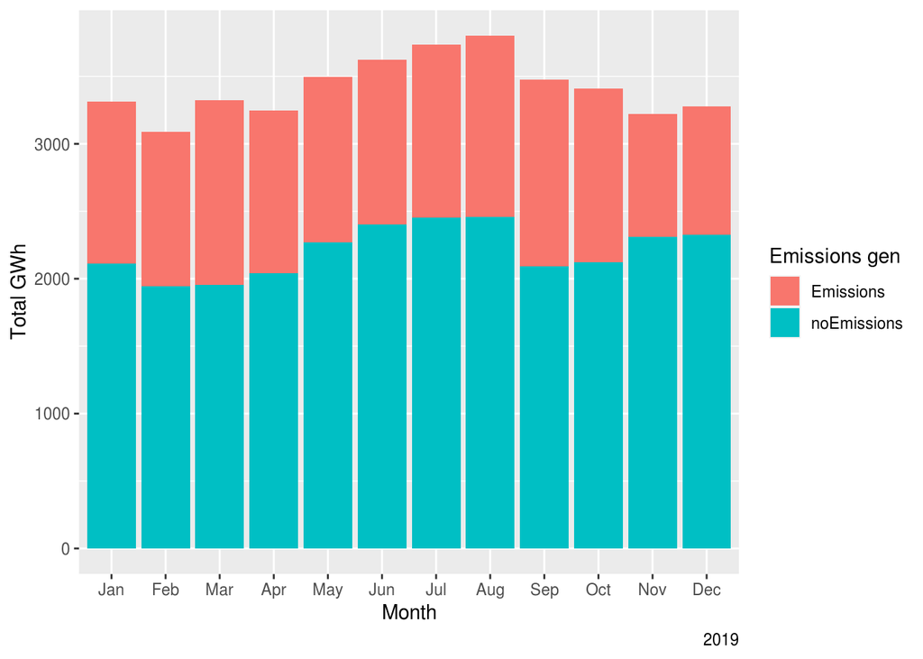

Figure 4.1: Total gen by month

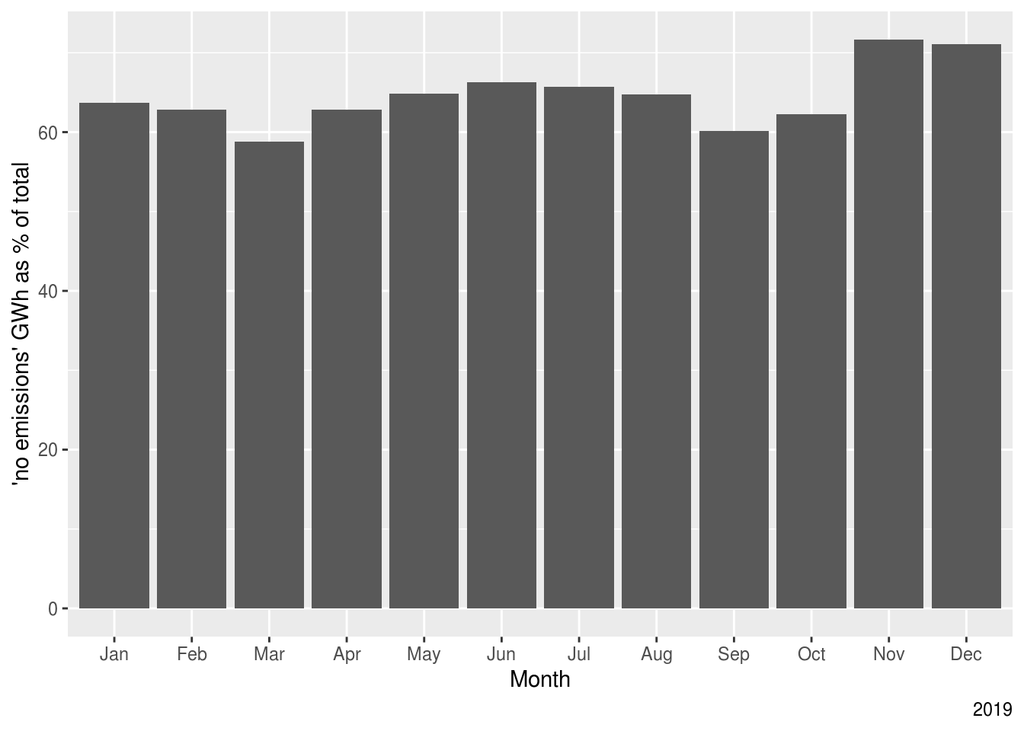

Figure 4.2: % no emissions gen by month

Figure 4.3 shows the % of total generation which is classified as ‘no emissions’ by time of day and date in 2019.

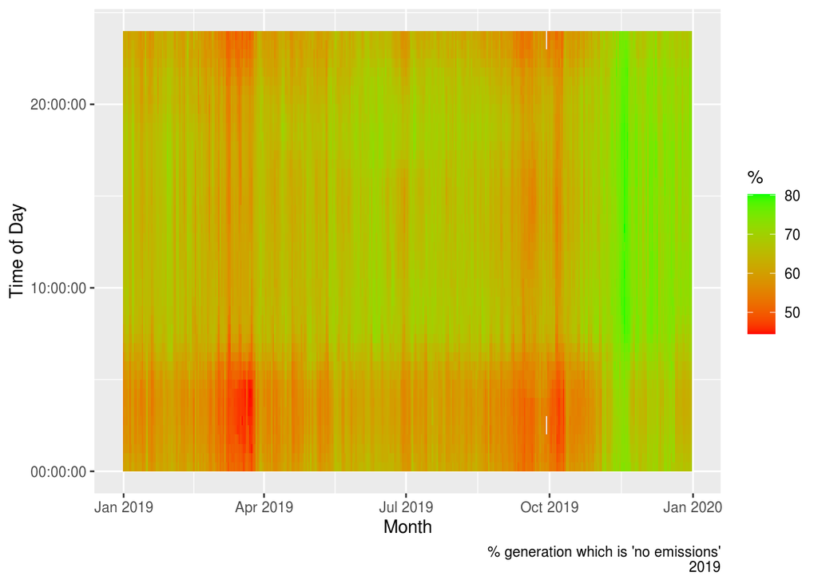

Figure 4.3: % no emissions gen by time and date

Figure 4.4 shows the % of total generation which is classified as ‘no emissions’ by half-hour in 2019.

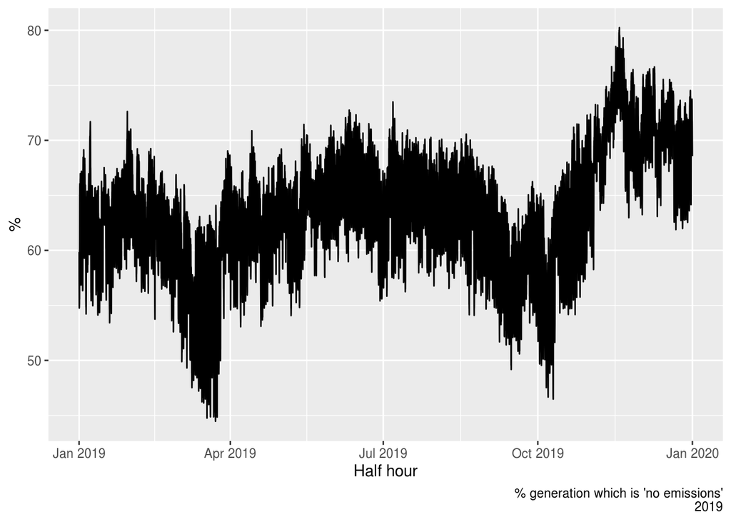

Figure 4.4: % no emissions gen by half hour

## 4.2 2009 - 2019

```
##
##    2009    2010    2011    2012    2013    2014    2015    2016    2017    2018
## 1192904 1221940 1252610 1220836 1242962 1234756 1222420 1210614 1225588 1240754
##    2019
## 1242194
```

Table 4.2: ‘No emissions’ gen as % of total gen by year

| year | % |
| --- | --- |
| 2009 | 61.52 |
| 2010 | 61.28 |
| 2011 | 63.24 |
| 2012 | 58.40 |
| 2013 | 60.18 |
| 2014 | 63.48 |
| 2015 | 62.84 |
| 2016 | 66.72 |
| 2017 | 63.58 |
| 2018 | 66.25 |
| 2019 | 64.56 |

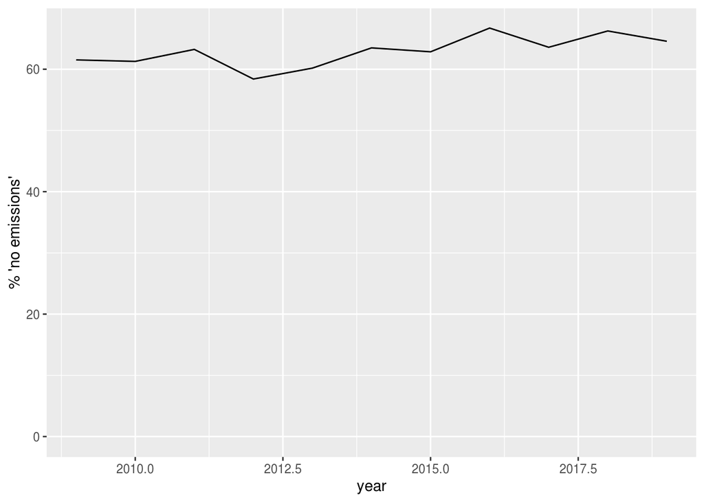

Figure 4.5: % no emissions gen by year

Figure 4.5 suggests a very slight increasing trend for no emissions.

Figure 4.6 indicates the extent to which this might be seasonal. Figure 4.7 makes the trends slightly more legible. Note it is important to consider seasonal and season-before climate patterns when interpreting these plots. For example [Autumn 2013](https://niwa.co.nz/climate/summaries/seasonal/autumn-2013) was unusually dry in some key hydro areas.

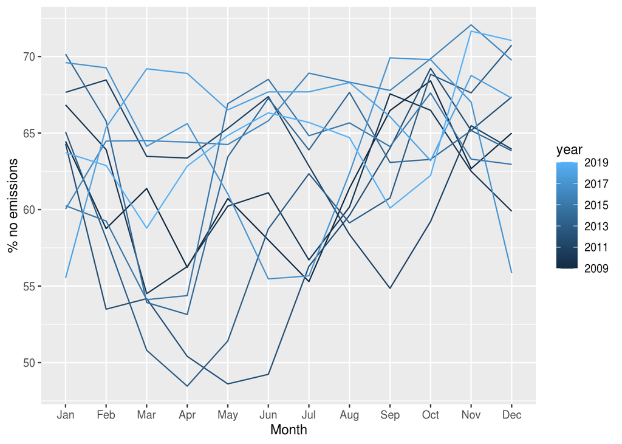

Figure 4.6: % no emissions by year

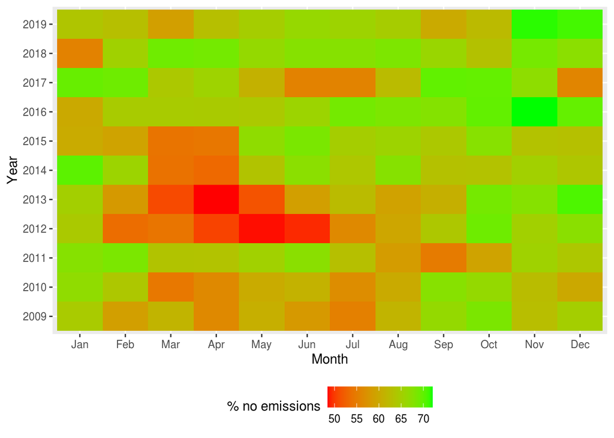

Figure 4.7: % no emissions by year

# 5 Conclusions

Doesn’t seem to be much evidence of substantial change based on this indicator alone. But:

- embedded wind & solar excluded
- this is not CO2e, it is just an indicator of generation in GWh being, in theory, free of emissions as definied by fuel type.

# 6 Annexes

## 6.1 Wholesale generation data (‘grid’)

Table 6.1: Data summary

| Name | allGridDT |
| --- | --- |
| Number of rows | 13708986 |
| Number of columns | 18 |
| _______________________ |  |
| Column type frequency: |  |
| character | 10 |
| Date | 1 |
| difftime | 1 |
| factor | 2 |
| numeric | 3 |
| POSIXct | 1 |
| ________________________ |  |
| Group variables | None |

**Variable type: character**

| skim_variable | n_missing | complete_rate | min | max | empty | n_unique | whitespace |
| --- | --- | --- | --- | --- | --- | --- | --- |
| Site_Code | 0 | 1 | 3 | 3 | 0 | 66 | 0 |
| POC_Code | 0 | 1 | 7 | 7 | 0 | 71 | 0 |
| Nwk_Code | 0 | 1 | 4 | 4 | 0 | 29 | 0 |
| Gen_Code | 0 | 1 | 3 | 15 | 0 | 69 | 0 |
| Fuel_Code | 0 | 1 | 3 | 7 | 0 | 8 | 0 |
| Tech_Code | 0 | 1 | 3 | 5 | 0 | 5 | 0 |
| Trading_date | 0 | 1 | 10 | 10 | 0 | 4077 | 0 |
| Time_Period | 0 | 1 | 3 | 4 | 0 | 48 | 0 |
| rDateTimeOrig | 0 | 1 | 20 | 20 | 0 | 195674 | 0 |
| noEmissions | 0 | 1 | 9 | 11 | 0 | 2 | 0 |

**Variable type: Date**

| skim_variable | n_missing | complete_rate | min | max | median | n_unique |
| --- | --- | --- | --- | --- | --- | --- |
| rDate | 0 | 1 | 2009-01-01 | 2020-02-29 | 2014-08-01 | 4077 |

**Variable type: difftime**

| skim_variable | n_missing | complete_rate | min | max | median | n_unique |
| --- | --- | --- | --- | --- | --- | --- |
| rTime | 0 | 1 | 900 secs | 85500 secs | 44100 secs | 48 |

**Variable type: factor**

| skim_variable | n_missing | complete_rate | ordered | n_unique | top_counts |
| --- | --- | --- | --- | --- | --- |
| rMonth | 0 | 1 | TRUE | 12 | Jan: 1250016, Dec: 1149408, May: 1149312, Jul: 1147248 |
| season | 0 | 1 | FALSE | 4 | Sum: 3538272, Win: 3403536, Aut: 3402768, Spr: 3364410 |

**Variable type: numeric**

| skim_variable | n_missing | complete_rate | mean | sd | p0 | p25 | p50 | p75 | p100 | hist |
| --- | --- | --- | --- | --- | --- | --- | --- | --- | --- | --- |
| kWh | 1570 | 1 | 33221.25 | 49965.58 | -2407 | 4685.77 | 16586.05 | 41328 | 484036 | ▇▁▁▁▁ |
| month | 0 | 1 | 6.45 | 3.48 | 1 | 3.00 | 6.00 | 9 | 12 | ▇▅▅▅▇ |
| year | 0 | 1 | 2014.10 | 3.22 | 2009 | 2011.00 | 2014.00 | 2017 | 2020 | ▇▆▆▅▆ |

**Variable type: POSIXct**

| skim_variable | n_missing | complete_rate | min | max | median | n_unique |
| --- | --- | --- | --- | --- | --- | --- |
| rDateTime | 0 | 1 | 2009-01-01 00:15:00 | 2020-02-29 23:45:00 | 2014-08-01 17:15:00 | 195674 |

## 6.2 Embedded generation data (‘nongrid’)

Table 6.2: Data summary

| Name | allEmbeddedDT |
| --- | --- |
| Number of rows | 2499650 |
| Number of columns | 15 |
| _______________________ |  |
| Column type frequency: |  |
| character | 9 |
| difftime | 1 |
| factor | 1 |
| numeric | 3 |
| POSIXct | 1 |
| ________________________ |  |
| Group variables | None |

**Variable type: character**

| skim_variable | n_missing | complete_rate | min | max | empty | n_unique | whitespace |
| --- | --- | --- | --- | --- | --- | --- | --- |
| POC | 0 | 1 | 7 | 7 | 0 | 23 | 0 |
| NWK_Code | 0 | 1 | 4 | 4 | 0 | 17 | 0 |
| Participant_Code | 0 | 1 | 4 | 4 | 0 | 39 | 0 |
| Loss_Code | 0 | 1 | 3 | 7 | 0 | 27 | 0 |
| Flow_Direction | 0 | 1 | 1 | 1 | 0 | 2 | 0 |
| Trading_date | 0 | 1 | 10 | 10 | 0 | 790 | 0 |
| Time_Period | 0 | 1 | 3 | 4 | 0 | 50 | 0 |
| rDate | 0 | 1 | 10 | 10 | 0 | 425 | 0 |
| rDateTimeOrig | 0 | 1 | 0 | 20 | 242 | 20401 | 0 |

**Variable type: difftime**

| skim_variable | n_missing | complete_rate | min | max | median | n_unique |
| --- | --- | --- | --- | --- | --- | --- |
| rTime | 242 | 1 | 900 secs | 85500 secs | 43200 secs | 48 |

**Variable type: factor**

| skim_variable | n_missing | complete_rate | ordered | n_unique | top_counts |
| --- | --- | --- | --- | --- | --- |
| rMonth | 242 | 1 | TRUE | 12 | Jan: 332112, Feb: 310608, Aug: 196800, May: 194112 |

**Variable type: numeric**

| skim_variable | n_missing | complete_rate | mean | sd | p0 | p25 | p50 | p75 | p100 | hist |
| --- | --- | --- | --- | --- | --- | --- | --- | --- | --- | --- |
| kWh | 286 | 1 | 3662.32 | 8723.46 | 0 | 0 | 45.56 | 1619.73 | 61151.56 | ▇▁▁▁▁ |
| month | 0 | 1 | 5.99 | 3.62 | 1 | 2 | 6.00 | 9.00 | 12.00 | ▇▃▃▃▆ |
| year | 0 | 1 | 269.64 | 666.70 | 1 | 9 | 18.00 | 27.00 | 2020.00 | ▇▁▁▁▁ |

**Variable type: POSIXct**

| skim_variable | n_missing | complete_rate | min | max | median | n_unique |
| --- | --- | --- | --- | --- | --- | --- |
| rDateTime | 242 | 1 | 1-01-20 00:15:00 | 2020-02-29 23:45:00 | 18-06-20 07:45:00 | 20400 |

# 7 Runtime

Analysis completed in 210.55 seconds ( 3.51 minutes) using knitr in [RStudio](http://www.rstudio.com) with R version 3.4.4 (2018-03-15) running on x86_64-pc-linux-gnu.

# 8 R environment

## 8.1 R packages used

- base R (R Core Team 2016)
- bookdown (Xie 2016a)
- data.table (Dowle et al. 2015)
- ggplot2 (Wickham 2009)
- kableExtra (Zhu 2018)
- knitr (Xie 2016b)
- lubridate (Grolemund and Wickham 2011)
- rmarkdown (Allaire et al. 2018)

# References

Allaire, JJ, Yihui Xie, Jonathan McPherson, Javier Luraschi, Kevin Ushey, Aron Atkins, Hadley Wickham, Joe Cheng, and Winston Chang. 2018. *Rmarkdown: Dynamic Documents for R*. https://CRAN.R-project.org/package=rmarkdown.

Dowle, M, A Srinivasan, T Short, S Lianoglou with contributions from R Saporta, and E Antonyan. 2015. *Data.table: Extension of Data.frame*. https://CRAN.R-project.org/package=data.table.

Grolemund, Garrett, and Hadley Wickham. 2011. “Dates and Times Made Easy with lubridate.” *Journal of Statistical Software* 40 (3): 1–25. http://www.jstatsoft.org/v40/i03/.

Khan, Imran, Michael W. Jack, and Janet Stephenson. 2018. “Analysis of Greenhouse Gas Emissions in Electricity Systems Using Time-Varying Carbon Intensity.” *Journal of Cleaner Production* 184 (May): 1091–1101. doi:10.1016/j.jclepro.2018.02.309.

R Core Team. 2016. *R: A Language and Environment for Statistical Computing*. Vienna, Austria: R Foundation for Statistical Computing. https://www.R-project.org/.

Wickham, Hadley. 2009. *Ggplot2: Elegant Graphics for Data Analysis*. Springer-Verlag New York. http://ggplot2.org.

Xie, Yihui. 2016a. *Bookdown: Authoring Books and Technical Documents with R Markdown*. Boca Raton, Florida: Chapman; Hall/CRC. https://github.com/rstudio/bookdown.

———. 2016b. *Knitr: A General-Purpose Package for Dynamic Report Generation in R*. https://CRAN.R-project.org/package=knitr.

Zhu, Hao. 2018. *KableExtra: Construct Complex Table with ’Kable’ and Pipe Syntax*. https://CRAN.R-project.org/package=kableExtra.